# incarceration

## Graph 2: Relationship Between Total Population and Prison Population

I have included a scatter plot to analyze the relationship between total population and prison population across various states. The graph depicts a positive correlation, indicating that as the population increases, so does the prison population, which is expected. However, there are a few outlier that either surpass or fall below this trend.When examining this relationship, we can gain insights into the extent of incarceration within a population and how it scales with population growth.

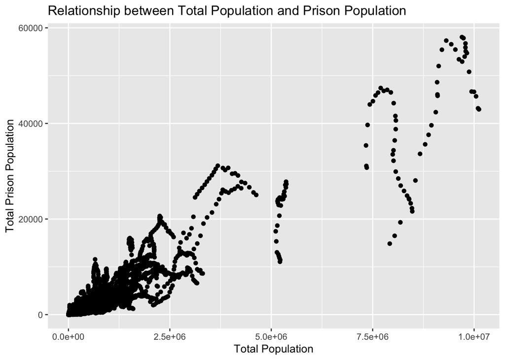

## Map in America Patterns Population

I use map to model the total prison population across different states through the different color gradient. By modelling the population of states we can considering not only population numbers but also demographic composition. This approach can help uncover correlations between racial demographics and incarceration rates. For instance, states with higher minority populations might have higher rates of imprisonment, which may reflect a potential systemic biases or racial disparities within the criminal justice system

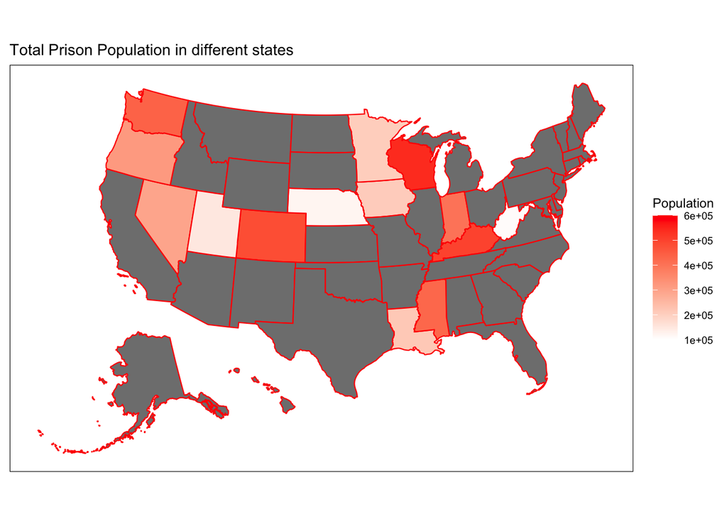